# SK_01_BOND_ISSUE_CUSIP_NUM

Issuer CUSIP number · Identifier report

## Overview

**Description**

Form990 Schedule KPart I - CUSIP number

**Table**

`SK-P01-T01-BOND-ISSUES` (many)

**Location code**

`SCHED-K-PART-01-COL-C`

**Family**

`SCHED-K-PART-01-COL-C`

**Data type**

numeric (xsd: CUSIPNumberType)

**Scope**

PC

**Status**

unreviewed

2

xpaths mapped (2 observed)

57,005

filings with a value

2009–2024

tax years observed

3

open flags (0 errors)

## Flags

| Severity | Flag | Xpath | Detail |
| --- | --- | --- | --- |
| ▲ warn | `TYPE_NUMERIC` | IRS990ScheduleK/TaxExemptBondsIssuesGrp/CUSIPNum | numeric variable; 10% of values parse as numbers |
| ▲ warn | `TYPE_NUMERIC` | IRS990ScheduleK/Form990ScheduleKPartI/CUSIPNumber | numeric variable; 3% of values parse as numbers |
| ⓘ info | `MANY_NOT_REPEATING` | IRS990ScheduleK/Form990ScheduleKPartI/CUSIPNumber | many-to-one table, but 51% of values sit in no repeating element |

## Xpaths

All mapped xpaths (under /Return/ReturnData or /Return/ReturnHeader), oldest first. Charts label each series by its xpath.

| Xpath | Form | First year | Last year | Versions | Filings | Repeats in |
| --- | --- | --- | --- | --- | --- | --- |
| IRS990ScheduleK/Form990ScheduleKPartI/CUSIPNumber | Sched K | 2009 | 2012 | 17 | 14,087 | 42.5% |
| IRS990ScheduleK/TaxExemptBondsIssuesGrp/CUSIPNum | Sched K | 2013 | 2024 | 36 | 42,918 | 43.0% |

## Coverage

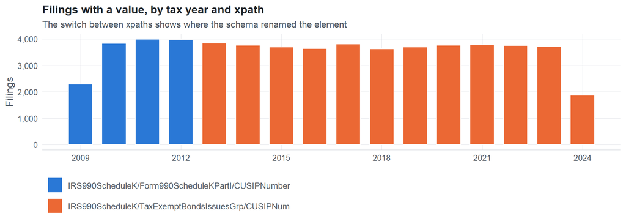

**Table view**

Table view: filings by tax year and series

| Tax year | IRS990ScheduleK/Form990ScheduleKPartI/CUSIPNumber | IRS990ScheduleK/TaxExemptBondsIssuesGrp/CUSIPNum |
| --- | --- | --- |
| 2009 | 2,291 | 0 |
| 2010 | 3,835 | 0 |
| 2011 | 3,985 | 0 |
| 2012 | 3,976 | 0 |
| 2013 | 0 | 3,846 |
| 2014 | 0 | 3,757 |
| 2015 | 0 | 3,689 |
| 2016 | 0 | 3,638 |
| 2017 | 0 | 3,809 |
| 2018 | 0 | 3,623 |
| 2019 | 0 | 3,691 |
| 2020 | 0 | 3,761 |
| 2021 | 0 | 3,778 |
| 2022 | 0 | 3,754 |
| 2023 | 0 | 3,709 |
| 2024 | 0 | 1,863 |

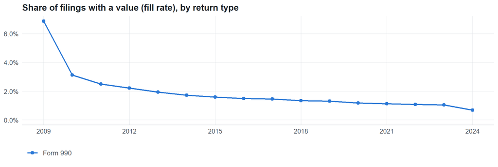

**Table view**

Table view: fill rate

| Tax year | Return type | Filings | All filings | Fill rate |
| --- | --- | --- | --- | --- |
| 2009 | Form 990 | 2,291 | 33,311 | 6.88% |
| 2010 | Form 990 | 3,835 | 123,025 | 3.12% |
| 2011 | Form 990 | 3,985 | 159,504 | 2.50% |
| 2012 | Form 990 | 3,976 | 179,688 | 2.21% |
| 2013 | Form 990 | 3,846 | 198,855 | 1.93% |
| 2014 | Form 990 | 3,757 | 218,619 | 1.72% |
| 2015 | Form 990 | 3,689 | 233,519 | 1.58% |
| 2016 | Form 990 | 3,638 | 243,903 | 1.49% |
| 2017 | Form 990 | 3,809 | 261,612 | 1.46% |
| 2018 | Form 990 | 3,623 | 271,442 | 1.33% |
| 2019 | Form 990 | 3,691 | 283,694 | 1.30% |
| 2020 | Form 990 | 3,761 | 320,342 | 1.17% |
| 2021 | Form 990 | 3,778 | 336,480 | 1.12% |
| 2022 | Form 990 | 3,754 | 349,055 | 1.08% |
| 2023 | Form 990 | 3,709 | 354,768 | 1.05% |
| 2024 | Form 990 | 1,863 | 277,298 | 0.67% |

## Repeating groups

Table cardinality in the concordance: **many**. 2 of 2 observed xpaths repeat within a filing.

Repeating element each xpath was observed in (from the raw indexed xpath)

| Xpath | Repeating element | Filings (summed over years) |
| --- | --- | --- |
| IRS990ScheduleK/Form990ScheduleKPartI/CUSIPNumber | (none) | 7423 |
| IRS990ScheduleK/Form990ScheduleKPartI/CUSIPNumber | IRS990ScheduleK | 367 |
| IRS990ScheduleK/Form990ScheduleKPartI/CUSIPNumber | IRS990ScheduleK/Form990ScheduleKPartI | 6643 |
| IRS990ScheduleK/TaxExemptBondsIssuesGrp/CUSIPNum | (none) | 21981 |
| IRS990ScheduleK/TaxExemptBondsIssuesGrp/CUSIPNum | IRS990ScheduleK | 1641 |
| IRS990ScheduleK/TaxExemptBondsIssuesGrp/CUSIPNum | IRS990ScheduleK/TaxExemptBondsIssuesGrp | 20890 |

## Values

[output not shown]

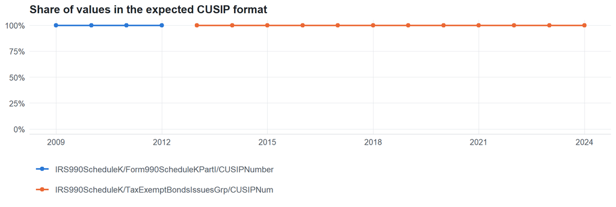

Value shapes (9 = digit, A = letter)

| Series | Shape | Expected | Filings |
| --- | --- | --- | --- |
| IRS990ScheduleK/Form990ScheduleKPartI/CUSIPNumber | 999999AA9 | yes | 6,235 |
| IRS990ScheduleK/Form990ScheduleKPartI/CUSIPNumber | 99999AAA9 | yes | 5,243 |
| IRS990ScheduleK/Form990ScheduleKPartI/CUSIPNumber | 999999A99 | yes | 1,125 |
| IRS990ScheduleK/Form990ScheduleKPartI/CUSIPNumber | 99999AA99 | yes | 1,010 |
| IRS990ScheduleK/Form990ScheduleKPartI/CUSIPNumber | AAAAAAAAA | yes | 867 |
| IRS990ScheduleK/Form990ScheduleKPartI/CUSIPNumber | 9999999A9 | yes | 122 |
| IRS990ScheduleK/TaxExemptBondsIssuesGrp/CUSIPNum | 99999AAA9 | yes | 17,423 |
| IRS990ScheduleK/TaxExemptBondsIssuesGrp/CUSIPNum | 999999AA9 | yes | 15,297 |
| IRS990ScheduleK/TaxExemptBondsIssuesGrp/CUSIPNum | 999999999 | yes | 5,725 |
| IRS990ScheduleK/TaxExemptBondsIssuesGrp/CUSIPNum | AAAAAAAAA | yes | 4,162 |
| IRS990ScheduleK/TaxExemptBondsIssuesGrp/CUSIPNum | 99999AA99 | yes | 2,113 |
| IRS990ScheduleK/TaxExemptBondsIssuesGrp/CUSIPNum | 999999A99 | yes | 1,051 |

## Examples

| Tax year | Return | Xpath | Organization | Value | Source |
| --- | --- | --- | --- | --- | --- |
| 2024 | 990 | IRS990ScheduleK/TaxExemptBondsIssuesGrp/CUSIPNum | THE CLEVELAND CLINIC FOUNDATION | 67756AJ37 | [XML](https://gt990datalake-rawdata.s3.amazonaws.com/EfileData/XmlFiles/202513189349302136_public.xml) |
| 2023 | 990 | IRS990ScheduleK/TaxExemptBondsIssuesGrp/CUSIPNum | Heritage Community Charter School Inc | 45129GDB8 | [XML](https://gt990datalake-rawdata.s3.amazonaws.com/EfileData/XmlFiles/202402569349300885_public.xml) |
| 2022 | 990 | IRS990ScheduleK/TaxExemptBondsIssuesGrp/CUSIPNum | THE PROTON THERAPY CENTER LLC | 49952MCG9 | [XML](https://gt990datalake-rawdata.s3.amazonaws.com/EfileData/XmlFiles/202323059349300927_public.xml) |
| 2021 | 990 | IRS990ScheduleK/TaxExemptBondsIssuesGrp/CUSIPNum | ADVENT CHRISTIAN VILLAGE INC | 869566AP4 | [XML](https://gt990datalake-rawdata.s3.amazonaws.com/EfileData/XmlFiles/202341009349300604_public.xml) |
| 2020 | 990 | IRS990ScheduleK/TaxExemptBondsIssuesGrp/CUSIPNum | MOBRIDGE REGIONAL HOSPITAL | 607429BA4 | [XML](https://gt990datalake-rawdata.s3.amazonaws.com/EfileData/XmlFiles/202212239349302471_public.xml) |
| 2019 | 990 | IRS990ScheduleK/TaxExemptBondsIssuesGrp/CUSIPNum | ST ANNE’S EPISCOPAL SCHOOL INC | NOTAPPLIC | [XML](https://gt990datalake-rawdata.s3.amazonaws.com/EfileData/XmlFiles/202101269349301820_public.xml) |
| 2018 | 990 | IRS990ScheduleK/TaxExemptBondsIssuesGrp/CUSIPNum | GIRLS PREPARATORY SCHOOL INC | NONEAVAIL | [XML](https://gt990datalake-rawdata.s3.amazonaws.com/EfileData/XmlFiles/201913199349306286_public.xml) |
| 2017 | 990 | IRS990ScheduleK/TaxExemptBondsIssuesGrp/CUSIPNum | MARSHALL MEDICAL CENTER | 13033FRK8 | [XML](https://gt990datalake-rawdata.s3.amazonaws.com/EfileData/XmlFiles/201922469349300702_public.xml) |
| 2016 | 990 | IRS990ScheduleK/TaxExemptBondsIssuesGrp/CUSIPNum | Bellin Psychiatric Center | 97712DLH7 | [XML](https://gt990datalake-rawdata.s3.amazonaws.com/EfileData/XmlFiles/201812279349301906_public.xml) |
| 2015 | 990 | IRS990ScheduleK/TaxExemptBondsIssuesGrp/CUSIPNum | METHODIST LE BONHEUR HEALTHCARE | 821697VM8 | [XML](https://gt990datalake-rawdata.s3.amazonaws.com/EfileData/XmlFiles/201613169349303066_public.xml) |
| 2014 | 990 | IRS990ScheduleK/TaxExemptBondsIssuesGrp/CUSIPNum | ARAPAHOE HOUSE INC | 196474M98 | [XML](https://gt990datalake-rawdata.s3.amazonaws.com/EfileData/XmlFiles/201611179349300921_public.xml) |
| 2013 | 990 | IRS990ScheduleK/TaxExemptBondsIssuesGrp/CUSIPNum | PRESBYTERIAN RETIREMENT VILLAGE OF RAPID CITY | 83755VWB6 | [XML](https://gt990datalake-rawdata.s3.amazonaws.com/EfileData/XmlFiles/201520969349300107_public.xml) |

## Reviewer checklist

- The definition matches the form line and instructions for every xpath’s schema years.
- Every xpath pooled here measures the same thing on the 990 and 990-EZ (close enough for analysis).
- The coverage chart has no unexplained gaps or jumps between tax years.
- Each open flag is fixed, or accepted with a note in validation_log.csv.
- The data type is text so leading zeros and letters survive.
- The identifier belongs to the entity the variable names (the filer, preparer, related organization…).
- Formats with and without punctuation (e.g. ZIP+4, dashes) are normalized consistently downstream.

Record the review as a row in `inst/extdata/src/validation_log.csv` (variable_name, reviewer, date, status, note). Evidence built 2026-09-23 17:09:04 MST from the ef2 DuckDB builds (tax years 2009–2024).